# Risk Factor Analysis

## Outcome Variable

**Outcome Variable:** whz

## Predictor Variables

**Intervention Variable:** perdiar24

**Adjustment Set:**

- arm
- sex
- meducyrs
- feducyrs
- hhwealth_quart
- hfoodsec
- vagbrth
- hdlvry
- W_birthwt
- W_birthlen
- single
- W_nrooms
- month
- brthmon
- impfloor
- impsan
- safeh20
- delta_meducyrs
- delta_feducyrs
- delta_hhwealth_quart
- delta_hfoodsec
- delta_vagbrth
- delta_hdlvry
- delta_W_birthwt
- delta_W_birthlen
- delta_single
- delta_W_nrooms
- delta_month
- delta_brthmon
- delta_impfloor
- delta_impsan
- delta_safeh20

## Stratifying Variables

The analysis was stratified on these variable(s):

- agecat
- studyid
- country

## Data Summary

| agecat | studyid | country | perdiar24 | n_cell | n |
| --- | --- | --- | --- | --- | --- |
| Birth | ki0047075b-MAL-ED | BANGLADESH | 0% | 14 | 215 |
| Birth | ki0047075b-MAL-ED | BANGLADESH | (0%, 5%] | 127 | 215 |
| Birth | ki0047075b-MAL-ED | BANGLADESH | >5% | 74 | 215 |
| Birth | ki0047075b-MAL-ED | BRAZIL | 0% | 34 | 62 |
| Birth | ki0047075b-MAL-ED | BRAZIL | (0%, 5%] | 26 | 62 |
| Birth | ki0047075b-MAL-ED | BRAZIL | >5% | 2 | 62 |
| Birth | ki0047075b-MAL-ED | INDIA | 0% | 5 | 45 |
| Birth | ki0047075b-MAL-ED | INDIA | (0%, 5%] | 31 | 45 |
| Birth | ki0047075b-MAL-ED | INDIA | >5% | 9 | 45 |
| Birth | ki0047075b-MAL-ED | NEPAL | 0% | 2 | 26 |
| Birth | ki0047075b-MAL-ED | NEPAL | (0%, 5%] | 19 | 26 |
| Birth | ki0047075b-MAL-ED | NEPAL | >5% | 5 | 26 |
| Birth | ki0047075b-MAL-ED | PERU | 0% | 21 | 228 |
| Birth | ki0047075b-MAL-ED | PERU | (0%, 5%] | 87 | 228 |
| Birth | ki0047075b-MAL-ED | PERU | >5% | 120 | 228 |
| Birth | ki0047075b-MAL-ED | SOUTH AFRICA | 0% | 42 | 112 |
| Birth | ki0047075b-MAL-ED | SOUTH AFRICA | (0%, 5%] | 69 | 112 |
| Birth | ki0047075b-MAL-ED | SOUTH AFRICA | >5% | 1 | 112 |
| Birth | ki0047075b-MAL-ED | TANZANIA, UNITED REPUBLIC OF | 0% | 7 | 115 |
| Birth | ki0047075b-MAL-ED | TANZANIA, UNITED REPUBLIC OF | (0%, 5%] | 77 | 115 |
| Birth | ki0047075b-MAL-ED | TANZANIA, UNITED REPUBLIC OF | >5% | 31 | 115 |
| Birth | ki1000109-EE | PAKISTAN | 0% | 115 | 177 |
| Birth | ki1000109-EE | PAKISTAN | (0%, 5%] | 62 | 177 |
| Birth | ki1000109-EE | PAKISTAN | >5% | 0 | 177 |
| Birth | ki1017093-NIH-Birth | BANGLADESH | 0% | 46 | 572 |
| Birth | ki1017093-NIH-Birth | BANGLADESH | (0%, 5%] | 327 | 572 |
| Birth | ki1017093-NIH-Birth | BANGLADESH | >5% | 199 | 572 |
| Birth | ki1017093b-PROVIDE | BANGLADESH | 0% | 55 | 532 |
| Birth | ki1017093b-PROVIDE | BANGLADESH | (0%, 5%] | 322 | 532 |
| Birth | ki1017093b-PROVIDE | BANGLADESH | >5% | 155 | 532 |

[output cut: 102 more lines]

The following strata were considered:

- agecat: 24 months, studyid: ki0047075b-MAL-ED, country: BANGLADESH
- agecat: 24 months, studyid: ki0047075b-MAL-ED, country: BRAZIL
- agecat: 24 months, studyid: ki0047075b-MAL-ED, country: INDIA
- agecat: 24 months, studyid: ki0047075b-MAL-ED, country: NEPAL
- agecat: 24 months, studyid: ki0047075b-MAL-ED, country: PERU
- agecat: 24 months, studyid: ki0047075b-MAL-ED, country: SOUTH AFRICA
- agecat: 24 months, studyid: ki0047075b-MAL-ED, country: TANZANIA, UNITED REPUBLIC OF
- agecat: 24 months, studyid: ki1000109-EE, country: PAKISTAN
- agecat: 24 months, studyid: ki1017093-NIH-Birth, country: BANGLADESH
- agecat: 24 months, studyid: ki1017093b-PROVIDE, country: BANGLADESH
- agecat: 24 months, studyid: ki1017093c-NIH-Crypto, country: BANGLADESH
- agecat: 24 months, studyid: ki1114097-CMIN, country: BANGLADESH
- agecat: 24 months, studyid: ki1114097-CONTENT, country: PERU
- agecat: 24 months, studyid: kiGH5241-JiVitA-4, country: BANGLADESH
- agecat: 6 months, studyid: ki0047075b-MAL-ED, country: BANGLADESH
- agecat: 6 months, studyid: ki0047075b-MAL-ED, country: BRAZIL
- agecat: 6 months, studyid: ki0047075b-MAL-ED, country: INDIA
- agecat: 6 months, studyid: ki0047075b-MAL-ED, country: NEPAL
- agecat: 6 months, studyid: ki0047075b-MAL-ED, country: PERU
- agecat: 6 months, studyid: ki0047075b-MAL-ED, country: SOUTH AFRICA
- agecat: 6 months, studyid: ki0047075b-MAL-ED, country: TANZANIA, UNITED REPUBLIC OF
- agecat: 6 months, studyid: ki1000109-EE, country: PAKISTAN
- agecat: 6 months, studyid: ki1000304b-SAS-FoodSuppl, country: INDIA
- agecat: 6 months, studyid: ki1017093-NIH-Birth, country: BANGLADESH
- agecat: 6 months, studyid: ki1017093b-PROVIDE, country: BANGLADESH
- agecat: 6 months, studyid: ki1017093c-NIH-Crypto, country: BANGLADESH
- agecat: 6 months, studyid: ki1112895-Guatemala BSC, country: GUATEMALA
- agecat: 6 months, studyid: ki1114097-CMIN, country: BANGLADESH
- agecat: 6 months, studyid: ki1114097-CONTENT, country: PERU
- agecat: 6 months, studyid: kiGH5241-JiVitA-4, country: BANGLADESH
- agecat: Birth, studyid: ki0047075b-MAL-ED, country: BANGLADESH
- agecat: Birth, studyid: ki0047075b-MAL-ED, country: BRAZIL
- agecat: Birth, studyid: ki0047075b-MAL-ED, country: INDIA
- agecat: Birth, studyid: ki0047075b-MAL-ED, country: NEPAL
- agecat: Birth, studyid: ki0047075b-MAL-ED, country: PERU
- agecat: Birth, studyid: ki0047075b-MAL-ED, country: SOUTH AFRICA
- agecat: Birth, studyid: ki0047075b-MAL-ED, country: TANZANIA, UNITED REPUBLIC OF
- agecat: Birth, studyid: ki1000109-EE, country: PAKISTAN
- agecat: Birth, studyid: ki1017093-NIH-Birth, country: BANGLADESH
- agecat: Birth, studyid: ki1017093b-PROVIDE, country: BANGLADESH
- agecat: Birth, studyid: ki1017093c-NIH-Crypto, country: BANGLADESH
- agecat: Birth, studyid: ki1114097-CMIN, country: BANGLADESH
- agecat: Birth, studyid: ki1114097-CONTENT, country: PERU
- agecat: Birth, studyid: kiGH5241-JiVitA-4, country: BANGLADESH

### Dropped Strata

Some strata were dropped due to rare outcomes:

- agecat: Birth, studyid: ki0047075b-MAL-ED, country: BRAZIL
- agecat: Birth, studyid: ki0047075b-MAL-ED, country: NEPAL
- agecat: Birth, studyid: ki0047075b-MAL-ED, country: SOUTH AFRICA
- agecat: Birth, studyid: ki1000109-EE, country: PAKISTAN
- agecat: Birth, studyid: ki1114097-CMIN, country: BANGLADESH
- agecat: Birth, studyid: ki1114097-CONTENT, country: PERU
- agecat: 6 months, studyid: ki0047075b-MAL-ED, country: BRAZIL
- agecat: 6 months, studyid: ki0047075b-MAL-ED, country: INDIA
- agecat: 6 months, studyid: ki0047075b-MAL-ED, country: SOUTH AFRICA
- agecat: 6 months, studyid: ki1000109-EE, country: PAKISTAN
- agecat: 6 months, studyid: ki1114097-CMIN, country: BANGLADESH
- agecat: 24 months, studyid: ki0047075b-MAL-ED, country: BRAZIL
- agecat: 24 months, studyid: ki0047075b-MAL-ED, country: INDIA
- agecat: 24 months, studyid: ki0047075b-MAL-ED, country: PERU
- agecat: 24 months, studyid: ki0047075b-MAL-ED, country: SOUTH AFRICA
- agecat: 24 months, studyid: ki1000109-EE, country: PAKISTAN
- agecat: 24 months, studyid: ki1114097-CMIN, country: BANGLADESH
- agecat: 24 months, studyid: ki1114097-CONTENT, country: PERU

## Methods Detail

We’re interested in the causal parameters $E[Y_a]$ for all values of $a \in \mathcal{A}$. These parameters represent the mean outcome if, possibly contrary to fact, we intervened to set all units to have $A=a$. Under the randomization and positivity assumptions, these are identified by the statistical parameters $\psi_a=E_W[E_{Y|A,W}(Y|A=a,W)]$. In addition, we’re interested in the mean of $Y$, $E[Y]$ under no intervention (the observed mean). We will estimate these parameters by using SuperLearner to fit the relevant likelihood factors – $E_{Y|A,W}(Y|A=a,W)$ and $p(A=a|W)$, and then updating our likelihood fit using a joint TMLE.

For unadjusted analyses ($W=\{\}$), initial likelihoods were estimated using Lrnr_glm to estimate the simple $E(Y|A)$ and Lrnr_mean to estimate $p(A)$. For adjusted analyses, a small library containing Lrnr_glmnet, Lrnr_xgboost, and Lrnr_mean was used.

Having estimated these parameters, we will then use the delta method to estimate relative risks and attributable risks relative to a prespecified baseline level of $A$.

# Results Detail

## Results Plots

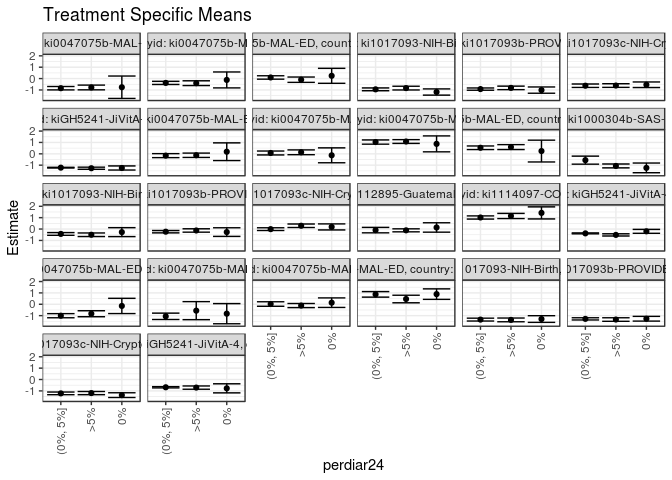

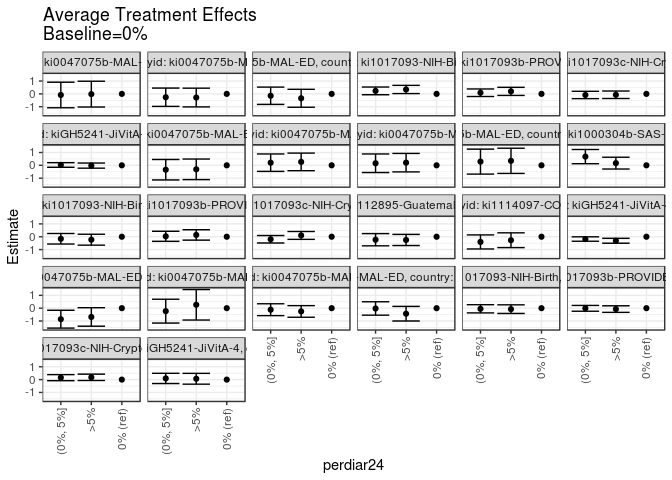

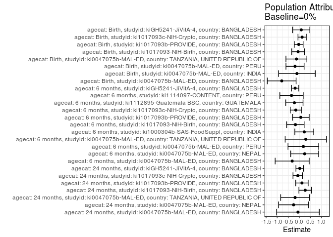

## Results Table

### Parameter: TSM

| agecat | studyid | country | intervention_level | baseline_level | estimate | ci_lower | ci_upper |
| --- | --- | --- | --- | --- | --- | --- | --- |
| Birth | ki0047075b-MAL-ED | BANGLADESH | 0% | NA | -0.1470795 | -0.8169167 | 0.5227576 |
| Birth | ki0047075b-MAL-ED | BANGLADESH | (0%, 5%] | NA | -1.0054741 | -1.1871931 | -0.8237550 |
| Birth | ki0047075b-MAL-ED | BANGLADESH | >5% | NA | -0.8312098 | -1.0955987 | -0.5668209 |
| Birth | ki0047075b-MAL-ED | INDIA | 0% | NA | -0.8260000 | -1.7120476 | 0.0600476 |
| Birth | ki0047075b-MAL-ED | INDIA | (0%, 5%] | NA | -1.0574194 | -1.3366625 | -0.7781762 |
| Birth | ki0047075b-MAL-ED | INDIA | >5% | NA | -0.5611111 | -1.3534381 | 0.2312159 |
| Birth | ki0047075b-MAL-ED | PERU | 0% | NA | 0.1405630 | -0.2775856 | 0.5587116 |
| Birth | ki0047075b-MAL-ED | PERU | (0%, 5%] | NA | 0.0218890 | -0.1757886 | 0.2195665 |
| Birth | ki0047075b-MAL-ED | PERU | >5% | NA | -0.1117209 | -0.2929117 | 0.0694700 |
| Birth | ki0047075b-MAL-ED | TANZANIA, UNITED REPUBLIC OF | 0% | NA | 0.8928571 | 0.4313181 | 1.3543962 |
| Birth | ki0047075b-MAL-ED | TANZANIA, UNITED REPUBLIC OF | (0%, 5%] | NA | 0.8712987 | 0.6273536 | 1.1152438 |
| Birth | ki0047075b-MAL-ED | TANZANIA, UNITED REPUBLIC OF | >5% | NA | 0.4625806 | 0.1300967 | 0.7950646 |
| Birth | ki1017093-NIH-Birth | BANGLADESH | 0% | NA | -1.2974079 | -1.5905894 | -1.0042265 |
| Birth | ki1017093-NIH-Birth | BANGLADESH | (0%, 5%] | NA | -1.3473548 | -1.4744556 | -1.2202540 |
| Birth | ki1017093-NIH-Birth | BANGLADESH | >5% | NA | -1.3738707 | -1.5370189 | -1.2107225 |
| Birth | ki1017093b-PROVIDE | BANGLADESH | 0% | NA | -1.2712648 | -1.4794700 | -1.0630596 |
| Birth | ki1017093b-PROVIDE | BANGLADESH | (0%, 5%] | NA | -1.2825337 | -1.3789865 | -1.1860808 |
| Birth | ki1017093b-PROVIDE | BANGLADESH | >5% | NA | -1.3415375 | -1.4969513 | -1.1861237 |
| Birth | ki1017093c-NIH-Crypto | BANGLADESH | 0% | NA | -1.3726872 | -1.5812272 | -1.1641473 |
| Birth | ki1017093c-NIH-Crypto | BANGLADESH | (0%, 5%] | NA | -1.2196559 | -1.3370592 | -1.1022526 |
| Birth | ki1017093c-NIH-Crypto | BANGLADESH | >5% | NA | -1.1930557 | -1.3328642 | -1.0532471 |
| Birth | kiGH5241-JiVitA-4 | BANGLADESH | 0% | NA | -0.7761850 | -1.1746078 | -0.3777621 |
| Birth | kiGH5241-JiVitA-4 | BANGLADESH | (0%, 5%] | NA | -0.6828633 | -0.7383450 | -0.6273816 |
| Birth | kiGH5241-JiVitA-4 | BANGLADESH | >5% | NA | -0.7104539 | -0.8539423 | -0.5669654 |
| 6 months | ki0047075b-MAL-ED | BANGLADESH | 0% | NA | 0.1833333 | -0.5948965 | 0.9615632 |
| 6 months | ki0047075b-MAL-ED | BANGLADESH | (0%, 5%] | NA | -0.1588028 | -0.3343167 | 0.0167111 |
| 6 months | ki0047075b-MAL-ED | BANGLADESH | >5% | NA | -0.1279928 | -0.3199980 | 0.0640124 |
| 6 months | ki0047075b-MAL-ED | NEPAL | 0% | NA | -0.1313550 | -0.7858673 | 0.5231572 |
| 6 months | ki0047075b-MAL-ED | NEPAL | (0%, 5%] | NA | 0.0737168 | -0.0982789 | 0.2457126 |
| 6 months | ki0047075b-MAL-ED | NEPAL | >5% | NA | 0.1346173 | -0.0766931 | 0.3459277 |
| 6 months | ki0047075b-MAL-ED | PERU | 0% | NA | 0.8728571 | 0.1723061 | 1.5734082 |
| 6 months | ki0047075b-MAL-ED | PERU | (0%, 5%] | NA | 1.0342813 | 0.8488952 | 1.2196675 |
| 6 months | ki0047075b-MAL-ED | PERU | >5% | NA | 1.0808068 | 0.9161635 | 1.2454501 |
| 6 months | ki0047075b-MAL-ED | TANZANIA, UNITED REPUBLIC OF | 0% | NA | 0.2427778 | -0.7161220 | 1.2016775 |
| 6 months | ki0047075b-MAL-ED | TANZANIA, UNITED REPUBLIC OF | (0%, 5%] | NA | 0.5318644 | 0.3720281 | 0.6917007 |
| 6 months | ki0047075b-MAL-ED | TANZANIA, UNITED REPUBLIC OF | >5% | NA | 0.5921585 | 0.3766024 | 0.8077146 |
| 6 months | ki1000304b-SAS-FoodSuppl | INDIA | 0% | NA | -1.2366257 | -1.6633897 | -0.8098618 |
| 6 months | ki1000304b-SAS-FoodSuppl | INDIA | (0%, 5%] | NA | -0.5577176 | -0.9121445 | -0.2032907 |
| 6 months | ki1000304b-SAS-FoodSuppl | INDIA | >5% | NA | -1.0663150 | -1.2363442 | -0.8962858 |
| 6 months | ki1017093-NIH-Birth | BANGLADESH | 0% | NA | -0.2716086 | -0.6642069 | 0.1209898 |
| 6 months | ki1017093-NIH-Birth | BANGLADESH | (0%, 5%] | NA | -0.4304391 | -0.5482706 | -0.3126076 |
| 6 months | ki1017093-NIH-Birth | BANGLADESH | >5% | NA | -0.5018488 | -0.6592265 | -0.3444711 |
| 6 months | ki1017093b-PROVIDE | BANGLADESH | 0% | NA | -0.2676030 | -0.6462330 | 0.1110269 |
| 6 months | ki1017093b-PROVIDE | BANGLADESH | (0%, 5%] | NA | -0.2332637 | -0.3357178 | -0.1308096 |
| 6 months | ki1017093b-PROVIDE | BANGLADESH | >5% | NA | -0.1264654 | -0.2735746 | 0.0206437 |
| 6 months | ki1017093c-NIH-Crypto | BANGLADESH | 0% | NA | 0.1881307 | -0.0777222 | 0.4539837 |
| 6 months | ki1017093c-NIH-Crypto | BANGLADESH | (0%, 5%] | NA | -0.0083650 | -0.1279007 | 0.1111706 |
| 6 months | ki1017093c-NIH-Crypto | BANGLADESH | >5% | NA | 0.2904208 | 0.1368927 | 0.4439488 |
| 6 months | ki1112895-Guatemala BSC | GUATEMALA | 0% | NA | 0.1377692 | -0.2764346 | 0.5519730 |
| 6 months | ki1112895-Guatemala BSC | GUATEMALA | (0%, 5%] | NA | -0.0948828 | -0.3336435 | 0.1438778 |
| 6 months | ki1112895-Guatemala BSC | GUATEMALA | >5% | NA | -0.1134496 | -0.2451541 | 0.0182549 |
| 6 months | ki1114097-CONTENT | PERU | 0% | NA | 1.4197500 | 0.8897030 | 1.9497970 |
| 6 months | ki1114097-CONTENT | PERU | (0%, 5%] | NA | 1.0154953 | 0.8771516 | 1.1538390 |
| 6 months | ki1114097-CONTENT | PERU | >5% | NA | 1.1491642 | 0.9229924 | 1.3753360 |
| 6 months | kiGH5241-JiVitA-4 | BANGLADESH | 0% | NA | -0.2015638 | -0.3722908 | -0.0308368 |
| 6 months | kiGH5241-JiVitA-4 | BANGLADESH | (0%, 5%] | NA | -0.3808146 | -0.4198100 | -0.3418192 |
| 6 months | kiGH5241-JiVitA-4 | BANGLADESH | >5% | NA | -0.5145287 | -0.6115816 | -0.4174758 |
| 24 months | ki0047075b-MAL-ED | BANGLADESH | 0% | NA | -0.7608333 | -1.7455859 | 0.2239193 |
| 24 months | ki0047075b-MAL-ED | BANGLADESH | (0%, 5%] | NA | -0.8460385 | -0.9966390 | -0.6954379 |
| 24 months | ki0047075b-MAL-ED | BANGLADESH | >5% | NA | -0.7806579 | -0.9895925 | -0.5717233 |
| 24 months | ki0047075b-MAL-ED | NEPAL | 0% | NA | -0.1189334 | -0.8194473 | 0.5815805 |
| 24 months | ki0047075b-MAL-ED | NEPAL | (0%, 5%] | NA | -0.3802666 | -0.5175902 | -0.2429430 |
| 24 months | ki0047075b-MAL-ED | NEPAL | >5% | NA | -0.4036394 | -0.6120716 | -0.1952072 |
| 24 months | ki0047075b-MAL-ED | TANZANIA, UNITED REPUBLIC OF | 0% | NA | 0.2433333 | -0.4146176 | 0.9012843 |
| 24 months | ki0047075b-MAL-ED | TANZANIA, UNITED REPUBLIC OF | (0%, 5%] | NA | 0.0977885 | -0.0521334 | 0.2477103 |
| 24 months | ki0047075b-MAL-ED | TANZANIA, UNITED REPUBLIC OF | >5% | NA | -0.0994231 | -0.3337823 | 0.1349362 |
| 24 months | ki1017093-NIH-Birth | BANGLADESH | 0% | NA | -1.1800000 | -1.4547770 | -0.9052230 |
| 24 months | ki1017093-NIH-Birth | BANGLADESH | (0%, 5%] | NA | -0.9456415 | -1.0692081 | -0.8220748 |
| 24 months | ki1017093-NIH-Birth | BANGLADESH | >5% | NA | -0.8370172 | -1.0005302 | -0.6735043 |
| 24 months | ki1017093b-PROVIDE | BANGLADESH | 0% | NA | -1.0127778 | -1.2883897 | -0.7371658 |
| 24 months | ki1017093b-PROVIDE | BANGLADESH | (0%, 5%] | NA | -0.9233081 | -1.0226788 | -0.8239373 |
| 24 months | ki1017093b-PROVIDE | BANGLADESH | >5% | NA | -0.8173851 | -0.9715768 | -0.6631933 |
| 24 months | ki1017093c-NIH-Crypto | BANGLADESH | 0% | NA | -0.5422511 | -0.7865732 | -0.2979289 |
| 24 months | ki1017093c-NIH-Crypto | BANGLADESH | (0%, 5%] | NA | -0.6267253 | -0.7766463 | -0.4768042 |
| 24 months | ki1017093c-NIH-Crypto | BANGLADESH | >5% | NA | -0.6122559 | -0.7720202 | -0.4524915 |
| 24 months | kiGH5241-JiVitA-4 | BANGLADESH | 0% | NA | -1.2448977 | -1.4241964 | -1.0655989 |
| 24 months | kiGH5241-JiVitA-4 | BANGLADESH | (0%, 5%] | NA | -1.2172204 | -1.2501034 | -1.1843373 |
| 24 months | kiGH5241-JiVitA-4 | BANGLADESH | >5% | NA | -1.2666855 | -1.3595637 | -1.1738072 |

### Parameter: E(Y)

| agecat | studyid | country | intervention_level | baseline_level | estimate | ci_lower | ci_upper |
| --- | --- | --- | --- | --- | --- | --- | --- |
| Birth | ki0047075b-MAL-ED | BANGLADESH | NA | NA | -0.9412093 | -1.0864308 | -0.7959878 |
| Birth | ki0047075b-MAL-ED | INDIA | NA | NA | -0.9324444 | -1.2067907 | -0.6580982 |
| Birth | ki0047075b-MAL-ED | PERU | NA | NA | -0.0520175 | -0.1725298 | 0.0684947 |
| Birth | ki0047075b-MAL-ED | TANZANIA, UNITED REPUBLIC OF | NA | NA | 0.7624348 | 0.5710709 | 0.9537986 |
| Birth | ki1017093-NIH-Birth | BANGLADESH | NA | NA | -1.3525437 | -1.4473932 | -1.2576942 |
| Birth | ki1017093b-PROVIDE | BANGLADESH | NA | NA | -1.2984586 | -1.3752758 | -1.2216415 |
| Birth | ki1017093c-NIH-Crypto | BANGLADESH | NA | NA | -1.2441513 | -1.3281130 | -1.1601897 |
| Birth | kiGH5241-JiVitA-4 | BANGLADESH | NA | NA | -0.6886269 | -0.7410452 | -0.6362086 |
| 6 months | ki0047075b-MAL-ED | BANGLADESH | NA | NA | -0.1383956 | -0.2672708 | -0.0095204 |
| 6 months | ki0047075b-MAL-ED | NEPAL | NA | NA | 0.1110452 | -0.0202712 | 0.2423616 |
| 6 months | ki0047075b-MAL-ED | PERU | NA | NA | 1.0568987 | 0.9352990 | 1.1784983 |
| 6 months | ki0047075b-MAL-ED | TANZANIA, UNITED REPUBLIC OF | NA | NA | 0.5362213 | 0.4049390 | 0.6675036 |
| 6 months | ki1000304b-SAS-FoodSuppl | INDIA | NA | NA | -1.0121579 | -1.1280429 | -0.8962729 |
| 6 months | ki1017093-NIH-Birth | BANGLADESH | NA | NA | -0.4474038 | -0.5378167 | -0.3569909 |
| 6 months | ki1017093b-PROVIDE | BANGLADESH | NA | NA | -0.1990907 | -0.2817968 | -0.1163845 |
| 6 months | ki1017093c-NIH-Crypto | BANGLADESH | NA | NA | 0.0297622 | -0.0491685 | 0.1086930 |
| 6 months | ki1112895-Guatemala BSC | GUATEMALA | NA | NA | -0.0840134 | -0.1945572 | 0.0265305 |
| 6 months | ki1114097-CONTENT | PERU | NA | NA | 1.0684318 | 0.9515274 | 1.1853362 |
| 6 months | kiGH5241-JiVitA-4 | BANGLADESH | NA | NA | -0.3898055 | -0.4270507 | -0.3525603 |
| 24 months | ki0047075b-MAL-ED | BANGLADESH | NA | NA | -0.8201887 | -0.9423967 | -0.6979806 |
| 24 months | ki0047075b-MAL-ED | NEPAL | NA | NA | -0.3764474 | -0.4898516 | -0.2630431 |
| 24 months | ki0047075b-MAL-ED | TANZANIA, UNITED REPUBLIC OF | NA | NA | 0.0539486 | -0.0712465 | 0.1791437 |
| 24 months | ki1017093-NIH-Birth | BANGLADESH | NA | NA | -0.9115790 | -1.0095022 | -0.8136559 |
| 24 months | ki1017093b-PROVIDE | BANGLADESH | NA | NA | -0.8928670 | -0.9755153 | -0.8102187 |
| 24 months | ki1017093c-NIH-Crypto | BANGLADESH | NA | NA | -0.6103502 | -0.7050157 | -0.5156847 |
| 24 months | kiGH5241-JiVitA-4 | BANGLADESH | NA | NA | -1.2231088 | -1.2549632 | -1.1912543 |

### Parameter: ATE

| agecat | studyid | country | intervention_level | baseline_level | estimate | ci_lower | ci_upper |
| --- | --- | --- | --- | --- | --- | --- | --- |
| Birth | ki0047075b-MAL-ED | BANGLADESH | 0% | 0% | 0.0000000 | 0.0000000 | 0.0000000 |
| Birth | ki0047075b-MAL-ED | BANGLADESH | (0%, 5%] | 0% | -0.8583945 | -1.5535609 | -0.1632281 |
| Birth | ki0047075b-MAL-ED | BANGLADESH | >5% | 0% | -0.6841302 | -1.4046202 | 0.0363598 |
| Birth | ki0047075b-MAL-ED | INDIA | 0% | 0% | 0.0000000 | 0.0000000 | 0.0000000 |
| Birth | ki0047075b-MAL-ED | INDIA | (0%, 5%] | 0% | -0.2314194 | -1.1604280 | 0.6975893 |
| Birth | ki0047075b-MAL-ED | INDIA | >5% | 0% | 0.2648889 | -0.9237500 | 1.4535278 |
| Birth | ki0047075b-MAL-ED | PERU | 0% | 0% | 0.0000000 | 0.0000000 | 0.0000000 |
| Birth | ki0047075b-MAL-ED | PERU | (0%, 5%] | 0% | -0.1186740 | -0.5815566 | 0.3442086 |
| Birth | ki0047075b-MAL-ED | PERU | >5% | 0% | -0.2522838 | -0.7044753 | 0.1999076 |
| Birth | ki0047075b-MAL-ED | TANZANIA, UNITED REPUBLIC OF | 0% | 0% | 0.0000000 | 0.0000000 | 0.0000000 |
| Birth | ki0047075b-MAL-ED | TANZANIA, UNITED REPUBLIC OF | (0%, 5%] | 0% | -0.0215584 | -0.5436001 | 0.5004833 |
| Birth | ki0047075b-MAL-ED | TANZANIA, UNITED REPUBLIC OF | >5% | 0% | -0.4302765 | -0.9991033 | 0.1385503 |
| Birth | ki1017093-NIH-Birth | BANGLADESH | 0% | 0% | 0.0000000 | 0.0000000 | 0.0000000 |
| Birth | ki1017093-NIH-Birth | BANGLADESH | (0%, 5%] | 0% | -0.0499469 | -0.3694175 | 0.2695237 |
| Birth | ki1017093-NIH-Birth | BANGLADESH | >5% | 0% | -0.0764628 | -0.4119098 | 0.2589842 |
| Birth | ki1017093b-PROVIDE | BANGLADESH | 0% | 0% | 0.0000000 | 0.0000000 | 0.0000000 |
| Birth | ki1017093b-PROVIDE | BANGLADESH | (0%, 5%] | 0% | -0.0112689 | -0.2364221 | 0.2138843 |
| Birth | ki1017093b-PROVIDE | BANGLADESH | >5% | 0% | -0.0702726 | -0.3259114 | 0.1853661 |
| Birth | ki1017093c-NIH-Crypto | BANGLADESH | 0% | 0% | 0.0000000 | 0.0000000 | 0.0000000 |
| Birth | ki1017093c-NIH-Crypto | BANGLADESH | (0%, 5%] | 0% | 0.1530313 | -0.0826203 | 0.3886829 |
| Birth | ki1017093c-NIH-Crypto | BANGLADESH | >5% | 0% | 0.1796316 | -0.0680305 | 0.4272936 |
| Birth | kiGH5241-JiVitA-4 | BANGLADESH | 0% | 0% | 0.0000000 | 0.0000000 | 0.0000000 |
| Birth | kiGH5241-JiVitA-4 | BANGLADESH | (0%, 5%] | 0% | 0.0933217 | -0.3060145 | 0.4926579 |
| Birth | kiGH5241-JiVitA-4 | BANGLADESH | >5% | 0% | 0.0657311 | -0.3553244 | 0.4867866 |
| 6 months | ki0047075b-MAL-ED | BANGLADESH | 0% | 0% | 0.0000000 | 0.0000000 | 0.0000000 |
| 6 months | ki0047075b-MAL-ED | BANGLADESH | (0%, 5%] | 0% | -0.3421362 | -1.1399123 | 0.4556400 |
| 6 months | ki0047075b-MAL-ED | BANGLADESH | >5% | 0% | -0.3113262 | -1.1128919 | 0.4902396 |
| 6 months | ki0047075b-MAL-ED | NEPAL | 0% | 0% | 0.0000000 | 0.0000000 | 0.0000000 |
| 6 months | ki0047075b-MAL-ED | NEPAL | (0%, 5%] | 0% | 0.2050719 | -0.4738376 | 0.8839814 |
| 6 months | ki0047075b-MAL-ED | NEPAL | >5% | 0% | 0.2659723 | -0.4202852 | 0.9522299 |
| 6 months | ki0047075b-MAL-ED | PERU | 0% | 0% | 0.0000000 | 0.0000000 | 0.0000000 |
| 6 months | ki0047075b-MAL-ED | PERU | (0%, 5%] | 0% | 0.1614242 | -0.5632411 | 0.8860895 |
| 6 months | ki0047075b-MAL-ED | PERU | >5% | 0% | 0.2079497 | -0.5116886 | 0.9275879 |
| 6 months | ki0047075b-MAL-ED | TANZANIA, UNITED REPUBLIC OF | 0% | 0% | 0.0000000 | 0.0000000 | 0.0000000 |
| 6 months | ki0047075b-MAL-ED | TANZANIA, UNITED REPUBLIC OF | (0%, 5%] | 0% | 0.2890866 | -0.6830432 | 1.2612164 |
| 6 months | ki0047075b-MAL-ED | TANZANIA, UNITED REPUBLIC OF | >5% | 0% | 0.3493807 | -0.6334485 | 1.3322099 |
| 6 months | ki1000304b-SAS-FoodSuppl | INDIA | 0% | 0% | 0.0000000 | 0.0000000 | 0.0000000 |
| 6 months | ki1000304b-SAS-FoodSuppl | INDIA | (0%, 5%] | 0% | 0.6789081 | 0.1253846 | 1.2324317 |
| 6 months | ki1000304b-SAS-FoodSuppl | INDIA | >5% | 0% | 0.1703108 | -0.2888625 | 0.6294840 |
| 6 months | ki1017093-NIH-Birth | BANGLADESH | 0% | 0% | 0.0000000 | 0.0000000 | 0.0000000 |
| 6 months | ki1017093-NIH-Birth | BANGLADESH | (0%, 5%] | 0% | -0.1588306 | -0.5697461 | 0.2520850 |
| 6 months | ki1017093-NIH-Birth | BANGLADESH | >5% | 0% | -0.2302403 | -0.6546438 | 0.1941632 |
| 6 months | ki1017093b-PROVIDE | BANGLADESH | 0% | 0% | 0.0000000 | 0.0000000 | 0.0000000 |
| 6 months | ki1017093b-PROVIDE | BANGLADESH | (0%, 5%] | 0% | 0.0343393 | -0.3576351 | 0.4263138 |
| 6 months | ki1017093b-PROVIDE | BANGLADESH | >5% | 0% | 0.1411376 | -0.2645174 | 0.5467926 |
| 6 months | ki1017093c-NIH-Crypto | BANGLADESH | 0% | 0% | 0.0000000 | 0.0000000 | 0.0000000 |
| 6 months | ki1017093c-NIH-Crypto | BANGLADESH | (0%, 5%] | 0% | -0.1964958 | -0.4873310 | 0.0943394 |
| 6 months | ki1017093c-NIH-Crypto | BANGLADESH | >5% | 0% | 0.1022900 | -0.2047373 | 0.4093173 |
| 6 months | ki1112895-Guatemala BSC | GUATEMALA | 0% | 0% | 0.0000000 | 0.0000000 | 0.0000000 |
| 6 months | ki1112895-Guatemala BSC | GUATEMALA | (0%, 5%] | 0% | -0.2326520 | -0.7098782 | 0.2445742 |
| 6 months | ki1112895-Guatemala BSC | GUATEMALA | >5% | 0% | -0.2512188 | -0.6851498 | 0.1827122 |
| 6 months | ki1114097-CONTENT | PERU | 0% | 0% | 0.0000000 | 0.0000000 | 0.0000000 |
| 6 months | ki1114097-CONTENT | PERU | (0%, 5%] | 0% | -0.4042547 | -0.9520583 | 0.1435489 |
| 6 months | ki1114097-CONTENT | PERU | >5% | 0% | -0.2705858 | -0.8468700 | 0.3056984 |
| 6 months | kiGH5241-JiVitA-4 | BANGLADESH | 0% | 0% | 0.0000000 | 0.0000000 | 0.0000000 |
| 6 months | kiGH5241-JiVitA-4 | BANGLADESH | (0%, 5%] | 0% | -0.1792508 | -0.3505924 | -0.0079092 |
| 6 months | kiGH5241-JiVitA-4 | BANGLADESH | >5% | 0% | -0.3129649 | -0.5028719 | -0.1230580 |
| 24 months | ki0047075b-MAL-ED | BANGLADESH | 0% | 0% | 0.0000000 | 0.0000000 | 0.0000000 |
| 24 months | ki0047075b-MAL-ED | BANGLADESH | (0%, 5%] | 0% | -0.0852051 | -1.0814070 | 0.9109967 |
| 24 months | ki0047075b-MAL-ED | BANGLADESH | >5% | 0% | -0.0198246 | -1.0264979 | 0.9868488 |
| 24 months | ki0047075b-MAL-ED | NEPAL | 0% | 0% | 0.0000000 | 0.0000000 | 0.0000000 |
| 24 months | ki0047075b-MAL-ED | NEPAL | (0%, 5%] | 0% | -0.2613332 | -0.9756944 | 0.4530280 |
| 24 months | ki0047075b-MAL-ED | NEPAL | >5% | 0% | -0.2847060 | -1.0160048 | 0.4465927 |
| 24 months | ki0047075b-MAL-ED | TANZANIA, UNITED REPUBLIC OF | 0% | 0% | 0.0000000 | 0.0000000 | 0.0000000 |
| 24 months | ki0047075b-MAL-ED | TANZANIA, UNITED REPUBLIC OF | (0%, 5%] | 0% | -0.1455449 | -0.8203604 | 0.5292706 |
| 24 months | ki0047075b-MAL-ED | TANZANIA, UNITED REPUBLIC OF | >5% | 0% | -0.3427564 | -1.0412002 | 0.3556873 |
| 24 months | ki1017093-NIH-Birth | BANGLADESH | 0% | 0% | 0.0000000 | 0.0000000 | 0.0000000 |
| 24 months | ki1017093-NIH-Birth | BANGLADESH | (0%, 5%] | 0% | 0.2343585 | -0.0669240 | 0.5356410 |
| 24 months | ki1017093-NIH-Birth | BANGLADESH | >5% | 0% | 0.3429828 | 0.0232346 | 0.6627310 |
| 24 months | ki1017093b-PROVIDE | BANGLADESH | 0% | 0% | 0.0000000 | 0.0000000 | 0.0000000 |
| 24 months | ki1017093b-PROVIDE | BANGLADESH | (0%, 5%] | 0% | 0.0894697 | -0.2035090 | 0.3824484 |
| 24 months | ki1017093b-PROVIDE | BANGLADESH | >5% | 0% | 0.1953927 | -0.1204190 | 0.5112044 |
| 24 months | ki1017093c-NIH-Crypto | BANGLADESH | 0% | 0% | 0.0000000 | 0.0000000 | 0.0000000 |
| 24 months | ki1017093c-NIH-Crypto | BANGLADESH | (0%, 5%] | 0% | -0.0844742 | -0.3689684 | 0.2000201 |
| 24 months | ki1017093c-NIH-Crypto | BANGLADESH | >5% | 0% | -0.0700048 | -0.3605429 | 0.2205334 |
| 24 months | kiGH5241-JiVitA-4 | BANGLADESH | 0% | 0% | 0.0000000 | 0.0000000 | 0.0000000 |
| 24 months | kiGH5241-JiVitA-4 | BANGLADESH | (0%, 5%] | 0% | 0.0276773 | -0.1519614 | 0.2073160 |
| 24 months | kiGH5241-JiVitA-4 | BANGLADESH | >5% | 0% | -0.0217878 | -0.2208426 | 0.1772669 |

### Parameter: PAR

| agecat | studyid | country | intervention_level | baseline_level | estimate | ci_lower | ci_upper |
| --- | --- | --- | --- | --- | --- | --- | --- |
| Birth | ki0047075b-MAL-ED | BANGLADESH | 0% | NA | -0.7941298 | -1.4442313 | -0.1440282 |
| Birth | ki0047075b-MAL-ED | INDIA | 0% | NA | -0.1064444 | -0.9346255 | 0.7217366 |
| Birth | ki0047075b-MAL-ED | PERU | 0% | NA | -0.1925805 | -0.6020353 | 0.2168742 |
| Birth | ki0047075b-MAL-ED | TANZANIA, UNITED REPUBLIC OF | 0% | NA | -0.1304224 | -0.6033978 | 0.3425531 |
| Birth | ki1017093-NIH-Birth | BANGLADESH | 0% | NA | -0.0551358 | -0.3404616 | 0.2301900 |
| Birth | ki1017093b-PROVIDE | BANGLADESH | 0% | NA | -0.0271938 | -0.2268400 | 0.1724524 |
| Birth | ki1017093c-NIH-Crypto | BANGLADESH | 0% | NA | 0.1285359 | -0.0583864 | 0.3154582 |
| Birth | kiGH5241-JiVitA-4 | BANGLADESH | 0% | NA | 0.0875581 | -0.3012992 | 0.4764155 |
| 6 months | ki0047075b-MAL-ED | BANGLADESH | 0% | NA | -0.3217289 | -1.0911237 | 0.4476659 |
| 6 months | ki0047075b-MAL-ED | NEPAL | 0% | NA | 0.2424002 | -0.3874372 | 0.8722377 |
| 6 months | ki0047075b-MAL-ED | PERU | 0% | NA | 0.1840415 | -0.5090605 | 0.8771435 |
| 6 months | ki0047075b-MAL-ED | TANZANIA, UNITED REPUBLIC OF | 0% | NA | 0.2934435 | -0.6391424 | 1.2260295 |
| 6 months | ki1000304b-SAS-FoodSuppl | INDIA | 0% | NA | 0.2244679 | -0.2018834 | 0.6508191 |
| 6 months | ki1017093-NIH-Birth | BANGLADESH | 0% | NA | -0.1757952 | -0.5699000 | 0.2183095 |
| 6 months | ki1017093b-PROVIDE | BANGLADESH | 0% | NA | 0.0685124 | -0.3102500 | 0.4472747 |
| 6 months | ki1017093c-NIH-Crypto | BANGLADESH | 0% | NA | -0.1583685 | -0.4096439 | 0.0929069 |
| 6 months | ki1112895-Guatemala BSC | GUATEMALA | 0% | NA | -0.2217826 | -0.6127854 | 0.1692203 |
| 6 months | ki1114097-CONTENT | PERU | 0% | NA | -0.3513182 | -0.8794617 | 0.1768252 |
| 6 months | kiGH5241-JiVitA-4 | BANGLADESH | 0% | NA | -0.1882417 | -0.3534363 | -0.0230471 |
| 24 months | ki0047075b-MAL-ED | BANGLADESH | 0% | NA | -0.0593553 | -1.0236072 | 0.9048965 |
| 24 months | ki0047075b-MAL-ED | NEPAL | 0% | NA | -0.2575140 | -0.9358375 | 0.4208095 |
| 24 months | ki0047075b-MAL-ED | TANZANIA, UNITED REPUBLIC OF | 0% | NA | -0.1893847 | -0.8407667 | 0.4619972 |
| 24 months | ki1017093-NIH-Birth | BANGLADESH | 0% | NA | 0.2684210 | -0.0167391 | 0.5535810 |
| 24 months | ki1017093b-PROVIDE | BANGLADESH | 0% | NA | 0.1199108 | -0.1611490 | 0.4009705 |
| 24 months | ki1017093c-NIH-Crypto | BANGLADESH | 0% | NA | -0.0680991 | -0.2843059 | 0.1481077 |
| 24 months | kiGH5241-JiVitA-4 | BANGLADESH | 0% | NA | 0.0217889 | -0.1512702 | 0.1948479 |